# Project Title - Data Analysis and Exploration using the covid-19 data set

In this project, We are going to make use of the python scraping library [urllib.request] to scrape the dataset.After scraping the data I will perform some data exploration, data analysis using [numpy, pandas] while answering the question on the impact of the COVID-19 worldwide and while also performing data visualisation using [seaborn, plotly.graph_objs and cufflinks].

## Downloading the Dataset

**TODO** - This is the url I used to get my data 'https://covid.ourworldindata.org/data/owid-covid-data.csv' then save the data set on a file called covid_19.csv.**Note as this url is updated daily some changes might occur everytime you scrape the data**.

Let's import the necessary libraries.

```python
import pandas as pd
import numpy as np
import urllib.request
```

Let's begin by scraping the data.

```python
urllib.request.urlretrieve(
    'https://covid.ourworldindata.org/data/owid-covid-data.csv', 'covid_19.csv')
```

```
('covid_19.csv', <http.client.HTTPMessage at 0x7feef464ebe0>)
```

Let us save and upload our work to Jovian before continuing.

```python
project_name = "covid-19-project" # change this (use lowercase letters and hyphens only)
```

```python
!pip install jovian --upgrade -q
```

```python
import jovian
```

```python
jovian.commit(project=project_name)
```

```
[jovian] Attempting to save notebook..
[jovian] Updating notebook "abdoulayekaloga059/covid-19-project" on https://jovian.ml/
[jovian] Uploading notebook..
[jovian] Capturing environment..
[jovian] Committed successfully! https://jovian.ml/abdoulayekaloga059/covid-19-project
```

```
'https://jovian.ml/abdoulayekaloga059/covid-19-project'
```

## Data Preparation and Cleaning

**TODO** - Data preparation and Cleaning are very important process that involved some of these step and are not limited by only these steps.

> - Load the dataset into a data frame using Pandas
> - Explore the number of rows & columns, ranges of values etc.
> - Handle missing, incorrect and invalid data
> - Perform any additional steps (parsing dates, creating additional columns, merging multiple dataset etc.)

Load the dataset into a data frame using Pandas

```python
covid_19 = pd.read_csv('covid_19.csv')
```

Explore the number of rows & columns, ranges of values etc.

```python
row, col = covid_19.shape
```

```python
print('There are {} rows and {} columns on this data set.'.format(row, col))
```

```
There are 49437 rows and 41 columns on this data set.
```

Let's see a random sample of the data

```python
covid_19.sample(5)
```

|  | iso_code | continent | location | date | total_cases | new_cases | new_cases_smoothed | total_deaths | new_deaths | new_deaths_smoothed | ... | gdp_per_capita | extreme_poverty | cardiovasc_death_rate | diabetes_prevalence | female_smokers | male_smokers | handwashing_facilities | hospital_beds_per_thousand | life_expectancy | human_development_index |
| --- | --- | --- | --- | --- | --- | --- | --- | --- | --- | --- | --- | --- | --- | --- | --- | --- | --- | --- | --- | --- | --- |
| 24700 | KWT | Asia | Kuwait | 2020-09-17 | 96999.0 | 698.0 | 702.429 | 571.0 | 3.0 | 2.714 | ... | 65530.537 | NaN | 132.235 | 15.84 | 2.7 | 37.0 | NaN | 2.000 | 75.49 | 0.803 |
| 26458 | LTU | Europe | Lithuania | 2020-01-16 | 0.0 | 0.0 | 0.000 | 0.0 | 0.0 | 0.000 | ... | 29524.265 | 0.7 | 342.989 | 3.67 | 21.3 | 38.0 | NaN | 6.560 | 75.93 | 0.858 |
| 26392 | LIE | Europe | Liechtenstein | 2020-08-23 | 101.0 | 1.0 | 1.143 | 1.0 | 0.0 | 0.000 | ... | NaN | NaN | NaN | 7.77 | NaN | NaN | NaN | 2.397 | 82.49 | 0.916 |
| 35714 | POL | Europe | Poland | 2020-08-31 | 66870.0 | 631.0 | 729.714 | 2033.0 | 1.0 | 11.143 | ... | 27216.445 | NaN | 227.331 | 5.91 | 23.3 | 33.1 | NaN | 6.620 | 78.73 | 0.865 |
| 19803 | HTI | North America | Haiti | 2020-06-17 | 4547.0 | 106.0 | 126.429 | 80.0 | 4.0 | 3.429 | ... | 1653.173 | 23.5 | 430.548 | 6.65 | 2.9 | 23.1 | 22.863 | 0.700 | 64.00 | 0.498 |

5 rows × 41 columns

Let's see the different type of data type

```python
covid_19.info()
```

```
<class 'pandas.core.frame.DataFrame'>
RangeIndex: 49437 entries, 0 to 49436
Data columns (total 41 columns):
 #   Column                           Non-Null Count  Dtype
---  ------                           --------------  -----
 0   iso_code                         49151 non-null  object
 1   continent                        48865 non-null  object
 2   location                         49437 non-null  object
 3   date                             49437 non-null  object
 4   total_cases                      48822 non-null  float64
 5   new_cases                        48600 non-null  float64
 6   new_cases_smoothed               47818 non-null  float64
 7   total_deaths                     48822 non-null  float64
 8   new_deaths                       48600 non-null  float64
 9   new_deaths_smoothed              47818 non-null  float64
```

[output cut: 33 more lines]

As expected, the columns are composed of string and float, where object represent string and float64 represent numeric decimal points,however, if we take look the dataset we have a date column and it is in string format.We will convert this column in date format using pd.to_datetime().

Let's try to covert the column into a date format.

```python
type(covid_19.date[0]) # example of the data type before conversion
```

```
str
```

```python
covid_19['date'] = pd.to_datetime(covid_19['date'])
```

```python
type(covid_19.date[0]) # after conversion
```

```
pandas._libs.tslibs.timestamps.Timestamp
```

```python
import jovian
```

```python
jovian.commit()
```

```
[jovian] Attempting to save notebook..
[jovian] Updating notebook "abdoulayekaloga059/covid-19-project" on https://jovian.ml/
[jovian] Uploading notebook..
[jovian] Capturing environment..
[jovian] Committed successfully! https://jovian.ml/abdoulayekaloga059/covid-19-project
```

```
'https://jovian.ml/abdoulayekaloga059/covid-19-project'
```

## Exploratory Analysis and Visualization

**TODO** - Where we go in-depth discovery of the dataset by performing queries and visualization to further understand the dataset and be able to answer all the questions.

Let's begin by importing`matplotlib.pyplot` and `seaborn`.

```python
import seaborn as sns
import matplotlib
import matplotlib.pyplot as plt
%matplotlib inline

sns.set_style('darkgrid')
matplotlib.rcParams['font.size'] = 14
matplotlib.rcParams['figure.figsize'] = (9, 5)
matplotlib.rcParams['figure.facecolor'] = '#00000000'
```

**Let's get basics statistical information like mean, standard deviation, minimum/maximum for each columns**

```python
covid_19.describe()
```

|  | total_cases | new_cases | new_cases_smoothed | total_deaths | new_deaths | new_deaths_smoothed | total_cases_per_million | new_cases_per_million | new_cases_smoothed_per_million | total_deaths_per_million | ... | gdp_per_capita | extreme_poverty | cardiovasc_death_rate | diabetes_prevalence | female_smokers | male_smokers | handwashing_facilities | hospital_beds_per_thousand | life_expectancy | human_development_index |
| --- | --- | --- | --- | --- | --- | --- | --- | --- | --- | --- | --- | --- | --- | --- | --- | --- | --- | --- | --- | --- | --- |
| count | 4.882200e+04 | 48600.000000 | 47818.000000 | 4.882200e+04 | 48600.000000 | 47818.000000 | 48536.000000 | 48536.000000 | 47753.000000 | 48536.000000 | ... | 43478.000000 | 29009.000000 | 44062.000000 | 45622.000000 | 34463.000000 | 34024.000000 | 20687.000000 | 39769.000000 | 48527.000000 | 42506.000000 |
| mean | 1.154113e+05 | 1534.481811 | 1515.997622 | 4.429453e+03 | 44.184156 | 44.147725 | 2136.683605 | 26.733964 | 26.199532 | 61.968315 | ... | 20823.393206 | 12.199762 | 251.787910 | 8.050106 | 10.794154 | 32.636013 | 52.350764 | 3.105795 | 73.998608 | 0.724136 |
| std | 1.193174e+06 | 13866.086380 | 13602.521219 | 4.105652e+04 | 370.740522 | 359.534365 | 4438.924628 | 80.337646 | 61.105417 | 148.614614 | ... | 20394.668051 | 19.281349 | 117.463592 | 4.151478 | 10.476395 | 13.427571 | 31.619692 | 2.523440 | 7.379638 | 0.152933 |
| min | 0.000000e+00 | -8261.000000 | -552.000000 | 0.000000e+00 | -1918.000000 | -232.143000 | 0.000000 | -2212.545000 | -269.978000 | 0.000000 | ... | 661.240000 | 0.100000 | 79.370000 | 0.990000 | 0.100000 | 7.700000 | 1.188000 | 0.100000 | 53.280000 | 0.354000 |
| 25% | 7.000000e+01 | 0.000000 | 0.714000 | 1.000000e+00 | 0.000000 | 0.000000 | 38.273000 | 0.000000 | 0.170000 | 0.061000 | ... | 5338.454000 | 0.500000 | 155.898000 | 5.310000 | 1.900000 | 21.400000 | 21.222000 | 1.300000 | 69.870000 | 0.606000 |
| 50% | 1.168000e+03 | 11.000000 | 16.143000 | 2.300000e+01 | 0.000000 | 0.286000 | 319.597000 | 1.704000 | 3.209000 | 5.716000 | ... | 14048.881000 | 2.000000 | 238.339000 | 7.110000 | 6.400000 | 31.400000 | 52.232000 | 2.500000 | 75.400000 | 0.754000 |
| 75% | 1.294600e+04 | 178.250000 | 184.714000 | 2.710000e+02 | 3.000000 | 3.286000 | 2216.936250 | 19.759000 | 21.841000 | 40.694000 | ... | 31400.840000 | 16.000000 | 318.991000 | 10.390000 | 19.600000 | 40.900000 | 83.741000 | 4.200000 | 79.380000 | 0.847000 |
| max | 3.728791e+07 | 385848.000000 | 327698.571000 | 1.073675e+06 | 10491.000000 | 7456.857000 | 44351.037000 | 4944.376000 | 1083.470000 | 1237.551000 | ... | 116935.600000 | 77.600000 | 724.417000 | 23.360000 | 44.000000 | 78.100000 | 98.999000 | 13.800000 | 86.750000 | 0.953000 |

8 rows × 36 columns

**Let's check if all columns have the same length**

```python
covid_19.count()
```

```
iso_code                           49151
continent                          48865
location                           49437
date                               49437
total_cases                        48822
new_cases                          48600
new_cases_smoothed                 47818
total_deaths                       48822
new_deaths                         48600
new_deaths_smoothed                47818
total_cases_per_million            48536
new_cases_per_million              48536
new_cases_smoothed_per_million     47753
total_deaths_per_million           48536
new_deaths_per_million             48536
new_deaths_smoothed_per_million    47753
new_tests                          17681
total_tests                        18080
total_tests_per_thousand           18080
new_tests_per_thousand             17681
new_tests_smoothed                 19950
new_tests_smoothed_per_thousand    19950
tests_per_case                     18370
positive_rate                      18830
tests_units                        20805
stringency_index                   40949
population                         49151
population_density                 46890
median_age                         44054
aged_65_older                      43396
aged_70_older                      43825
gdp_per_capita                     43478
extreme_poverty                    29009
cardiovasc_death_rate              44062
diabetes_prevalence                45622
female_smokers                     34463
male_smokers                       34024
handwashing_facilities             20687
hospital_beds_per_thousand         39769
life_expectancy                    48527
human_development_index            42506
dtype: int64
```

```python
print('We see that not all columns have {} valid input. The count function only take into consideration real input and ignore all NAN values.'.format(row))
```

```
We see that not all columns have 49437 valid input. The count function only take into consideration real input and ignore all NAN values.
```

**How many Nas the dataset has for each column**

```python
covid_19.isna().sum()
```

```
iso_code                             286
continent                            572
location                               0
date                                   0
total_cases                          615
new_cases                            837
new_cases_smoothed                  1619
total_deaths                         615
new_deaths                           837
new_deaths_smoothed                 1619
total_cases_per_million              901
new_cases_per_million                901
new_cases_smoothed_per_million      1684
total_deaths_per_million             901
new_deaths_per_million               901
new_deaths_smoothed_per_million     1684
new_tests                          31756
total_tests                        31357
total_tests_per_thousand           31357
new_tests_per_thousand             31756
new_tests_smoothed                 29487
new_tests_smoothed_per_thousand    29487
tests_per_case                     31067
positive_rate                      30607
tests_units                        28632
stringency_index                    8488
population                           286
population_density                  2547
median_age                          5383
aged_65_older                       6041
aged_70_older                       5612
gdp_per_capita                      5959
extreme_poverty                    20428
cardiovasc_death_rate               5375
diabetes_prevalence                 3815
female_smokers                     14974
male_smokers                       15413
handwashing_facilities             28750
hospital_beds_per_thousand          9668
life_expectancy                      910
human_development_index             6931
dtype: int64
```

We see the total number of Nas in each columns is huge thus we decide not to drop any rows or columns as dropping any row might affect the purpose of the answers we trying to seek.

### Group and Summarize categorical variables

**Let's get basics statistical information like mean, standard deviation, minimum/maximum for each country location**

```python
covid_19.groupby('location').describe().head(5)
```

| location | total_cases count | total_cases mean | total_cases std | total_cases min | total_cases 25% | total_cases 50% | total_cases 75% | total_cases max | new_cases count | new_cases mean | ... | life_expectancy 75% | life_expectancy max | human_development_index count | human_development_index mean | human_development_index std | human_development_index min | human_development_index 25% | human_development_index 50% | human_development_index 75% | human_development_index max |
| --- | --- | --- | --- | --- | --- | --- | --- | --- | --- | --- | --- | --- | --- | --- | --- | --- | --- | --- | --- | --- | --- |
| Afghanistan | 276.0 | 17413.934783 | 17059.408324 | 0.0 | 22.00 | 11502.0 | 36719.25 | 39703.0 | 276.0 | 143.851449 | ... | 64.83 | 64.83 | 286.0 | 0.498 | 0.000000e+00 | 0.498 | 0.498 | 0.498 | 0.498 | 0.498 |
| Albania | 217.0 | 4344.391705 | 4571.850407 | 2.0 | 782.00 | 2114.0 | 7499.00 | 15231.0 | 217.0 | 70.188940 | ... | 78.57 | 78.57 | 217.0 | 0.785 | 0.000000e+00 | 0.785 | 0.785 | 0.785 | 0.785 | 0.785 |
| Algeria | 281.0 | 15887.362989 | 18345.764883 | 0.0 | 37.00 | 8113.0 | 30950.00 | 52940.0 | 281.0 | 188.398577 | ... | 76.88 | 76.88 | 286.0 | 0.754 | 1.112169e-16 | 0.754 | 0.754 | 0.754 | 0.754 | 0.754 |
| Andorra | 212.0 | 935.750000 | 485.243574 | 1.0 | 750.75 | 855.0 | 1009.75 | 2696.0 | 212.0 | 12.716981 | ... | 83.73 | 83.73 | 218.0 | 0.858 | 1.112778e-16 | 0.858 | 0.858 | 0.858 | 0.858 | 0.858 |
| Angola | 204.0 | 1223.524510 | 1645.113770 | 2.0 | 45.00 | 287.5 | 2022.25 | 6031.0 | 204.0 | 29.563725 | ... | 61.15 | 61.15 | 204.0 | 0.581 | 1.112954e-16 | 0.581 | 0.581 | 0.581 | 0.581 | 0.581 |

5 rows × 288 columns

**Let's check to see if each column has the same amount of inputs across all columns**

```python
covid_19.groupby('location').count()
```

| location | iso_code | continent | date | total_cases | new_cases | new_cases_smoothed | total_deaths | new_deaths | new_deaths_smoothed | total_cases_per_million | ... | gdp_per_capita | extreme_poverty | cardiovasc_death_rate | diabetes_prevalence | female_smokers | male_smokers | handwashing_facilities | hospital_beds_per_thousand | life_expectancy | human_development_index |
| --- | --- | --- | --- | --- | --- | --- | --- | --- | --- | --- | --- | --- | --- | --- | --- | --- | --- | --- | --- | --- | --- |
| Afghanistan | 286 | 286 | 286 | 276 | 276 | 280 | 276 | 276 | 280 | 276 | ... | 286 | 0 | 286 | 286 | 0 | 0 | 286 | 286 | 286 | 286 |
| Albania | 217 | 217 | 217 | 217 | 217 | 211 | 217 | 217 | 211 | 217 | ... | 217 | 217 | 217 | 217 | 217 | 217 | 0 | 217 | 217 | 217 |
| Algeria | 286 | 286 | 286 | 281 | 281 | 280 | 281 | 281 | 280 | 281 | ... | 286 | 286 | 286 | 286 | 286 | 286 | 286 | 286 | 286 | 286 |
| Andorra | 218 | 218 | 218 | 212 | 212 | 217 | 212 | 212 | 217 | 212 | ... | 0 | 0 | 218 | 218 | 218 | 218 | 0 | 0 | 218 | 218 |
| Angola | 204 | 204 | 204 | 204 | 204 | 198 | 204 | 204 | 198 | 204 | ... | 204 | 0 | 204 | 204 | 0 | 0 | 204 | 0 | 204 | 204 |
| ... | ... | ... | ... | ... | ... | ... | ... | ... | ... | ... | ... | ... | ... | ... | ... | ... | ... | ... | ... | ... | ... |
| Western Sahara | 169 | 169 | 169 | 169 | 169 | 163 | 169 | 169 | 163 | 169 | ... | 0 | 0 | 0 | 0 | 0 | 0 | 0 | 0 | 169 | 0 |
| World | 286 | 0 | 286 | 286 | 286 | 280 | 286 | 286 | 280 | 286 | ... | 286 | 286 | 286 | 286 | 286 | 286 | 286 | 286 | 286 | 0 |
| Yemen | 185 | 185 | 185 | 185 | 185 | 179 | 185 | 185 | 179 | 185 | ... | 185 | 185 | 185 | 185 | 185 | 185 | 185 | 185 | 185 | 185 |
| Zambia | 207 | 207 | 207 | 207 | 207 | 201 | 207 | 207 | 201 | 207 | ... | 207 | 207 | 207 | 207 | 207 | 207 | 207 | 207 | 207 | 207 |
| Zimbabwe | 205 | 205 | 205 | 205 | 205 | 199 | 205 | 205 | 199 | 205 | ... | 205 | 205 | 205 | 205 | 205 | 205 | 205 | 205 | 205 | 205 |

212 rows × 40 columns

Again, we can see that each location do not have a constant value accross all columns.Inconsistency.

**TODO** - What is the total number of cases in each country location ?

Installing the plotly library for visual graphical interaction, for more information visit this links https://plotly.com/python/

```python
pip install plotly
```

```python
# Import libraries
import plotly.graph_objs as go
from plotly.offline import init_notebook_mode,iplot,plot
init_notebook_mode(connected=True)
```

In order to answer to question and be able to plot the figures on map, we need to group the location using the groupby function then reset the location from an index column to regular column.

```python
covid_19_df = covid_19.groupby('location').sum()
covid_19_df = covid_19_df.reset_index()
covid_19_df.head()
```

|  | location | total_cases | new_cases | new_cases_smoothed | total_deaths | new_deaths | new_deaths_smoothed | total_cases_per_million | new_cases_per_million | new_cases_smoothed_per_million | ... | gdp_per_capita | extreme_poverty | cardiovasc_death_rate | diabetes_prevalence | female_smokers | male_smokers | handwashing_facilities | hospital_beds_per_thousand | life_expectancy | human_development_index |
| --- | --- | --- | --- | --- | --- | --- | --- | --- | --- | --- | --- | --- | --- | --- | --- | --- | --- | --- | --- | --- | --- |
| 0 | Afghanistan | 4806246.0 | 39703.0 | 39584.278 | 154011.0 | 1473.0 | 1469.434 | 123463.943 | 1019.904 | 1016.848 | ... | 515940.282 | 0.0 | 170750.294 | 2742.74 | 0.0 | 0.0 | 10795.356 | 143.00 | 18541.38 | 142.428 |
| 1 | Albania | 942733.0 | 15231.0 | 14726.430 | 27568.0 | 416.0 | 406.155 | 327588.090 | 5292.580 | 5117.257 | ... | 2561344.527 | 238.7 | 66010.315 | 2187.36 | 1540.7 | 11110.4 | 0.000 | 627.13 | 17049.69 | 170.345 |
| 2 | Algeria | 4464349.0 | 52940.0 | 52532.425 | 191795.0 | 1795.0 | 1778.134 | 101807.134 | 1207.270 | 1197.976 | ... | 3979357.954 | 143.0 | 79612.104 | 1924.78 | 200.2 | 8694.4 | 23949.926 | 543.40 | 21987.68 | 215.644 |
| 3 | Andorra | 198379.0 | 2696.0 | 2481.722 | 9386.0 | 55.0 | 53.717 | 2567514.386 | 34892.888 | 32119.509 | ... | 0.000 | 0.0 | 23791.430 | 1737.46 | 6322.0 | 8240.4 | 0.000 | 0.00 | 18253.14 | 187.044 |
| 4 | Angola | 249599.0 | 6031.0 | 5718.428 | 10013.0 | 212.0 | 203.439 | 7594.379 | 183.504 | 173.989 | ... | 1187176.980 | 0.0 | 56313.180 | 803.76 | 0.0 | 0.0 | 5439.456 | 0.00 | 12474.60 | 118.524 |

5 rows × 37 columns

```python
data = dict(type = 'choropleth',
            marker_line_width=0.5,
            locations = covid_19_df['location'],
           locationmode = 'country names',
           z = covid_19_df['new_cases'],
           text = covid_19_df['location'],
           colorbar = {'title': 'Total Number Of New Cases Up Todate'},
           )



layout = dict(title = 'Covid-19 Total Number Of New Cases',
             geo = dict(showframe = False,  showcoastlines=False, projection = {'type':'orthographic'} ))
choromap = go.Figure(data = [data], layout = layout)
plot(choromap, validate = False)
```

```
'temp-plot.html'
```

Check inside the directory folder, there is html file called temp-plot.html

**TODO** - Plot total tests per thousand for each country GDP per capita ?

install cufflinks another graphical interaction, for further information check this link: https://github.com/santosjorge/cufflinks

```python
pip install cufflinks
```

```python
#Import these libraries
import cufflinks as cf
cf.go_offline()
from plotly import __version__
from plotly.offline import download_plotlyjs, init_notebook_mode, plot, iplot
```

```python
gdp_df = covid_19_df[covid_19_df['population'] >  10000000].sort_values('gdp_per_capita', ascending= False)
```

```python
gdp_df.iplot(kind = 'scatter', y = 'total_tests_per_thousand', x = 'gdp_per_capita', mode = 'markers', text = 'location', title = 'Total Covid-19 test per 1000000 vs GDP per capita')
```

[interactive chart not shown]

We can see that countries location with lowest GDP per capita had few test ran compared to richer countries.

**TODO** Plot the Positive rate of each location ?

```python
data = dict(type = 'choropleth',
            marker_line_width=0.5,
            locations = covid_19_df['location'],
           locationmode = 'country names',
           z = covid_19_df['positive_rate'],
           text = covid_19_df['location'],
           colorbar = {'title': 'Total Number Of New Cases Up Todate'},
           )



layout = dict(title = 'Covid-19 Total Number Of New Cases',
             geo = dict(showframe = False,  showcoastlines=False, projection = {'type':'mercator'} ))
choromap = go.Figure(data = [data], layout = layout)
plot(choromap, validate = False)
```

```
'temp-plot.html'
```

The positive rate is good way of understanding the location where the tests are returning positive results.It shows which locations are adequately testing and also help us understandand the spread of the virus. Some location do not have any data because the data were not provide or the amount of cases or test is too low to be counted.

**TODO** - Plot the total number of cases in each continent in million ?

```python
total_cases = covid_19.groupby('continent')['total_cases'].max()
total_cases = pd.DataFrame(total_cases)
total_cases.reset_index(inplace = True)
```

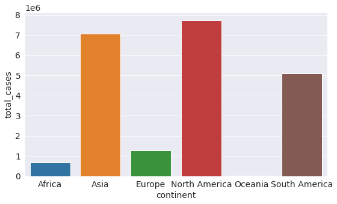

```python
sns.barplot(x = 'continent', y= 'total_cases' , data = total_cases)
```

We can see that North America, Asia and South America had the highest total cases.

**TODO** - Plot the total deaths cases in each continent in million ?

```python
total_deaths = covid_19.groupby('continent')['total_deaths'].max()
total_deaths = pd.DataFrame(total_deaths)
total_deaths.reset_index(inplace = True)
```

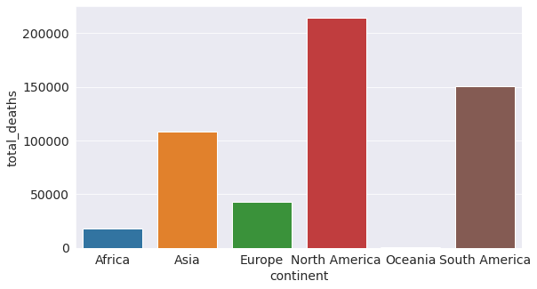

```python
sns.barplot(x = 'continent', y= 'total_deaths' , data = total_deaths)
```

We can see that North America had the highest total deaths rate.

Let us save and upload our work to Jovian before continuing

```python
import jovian
```

```python
jovian.commit()
```

```
[jovian] Attempting to save notebook..
[jovian] Updating notebook "abdoulayekaloga059/covid-19-project" on https://jovian.ml/
[jovian] Uploading notebook..
[jovian] Capturing environment..
[jovian] Committed successfully! https://jovian.ml/abdoulayekaloga059/covid-19-project
```

```
'https://jovian.ml/abdoulayekaloga059/covid-19-project'
```